# Axis Adjust

hou

2018/9/18

在平时画图时，经常根据实际情况需要调整坐标轴，比如坐标轴刻度大小、坐标轴标签大小等等。所以在这里简单汇总一下常用的坐标轴调整方法。同样分为基础画图 Plot 和ggplot2两块。

## Plot

首先我们画一个简单的图:

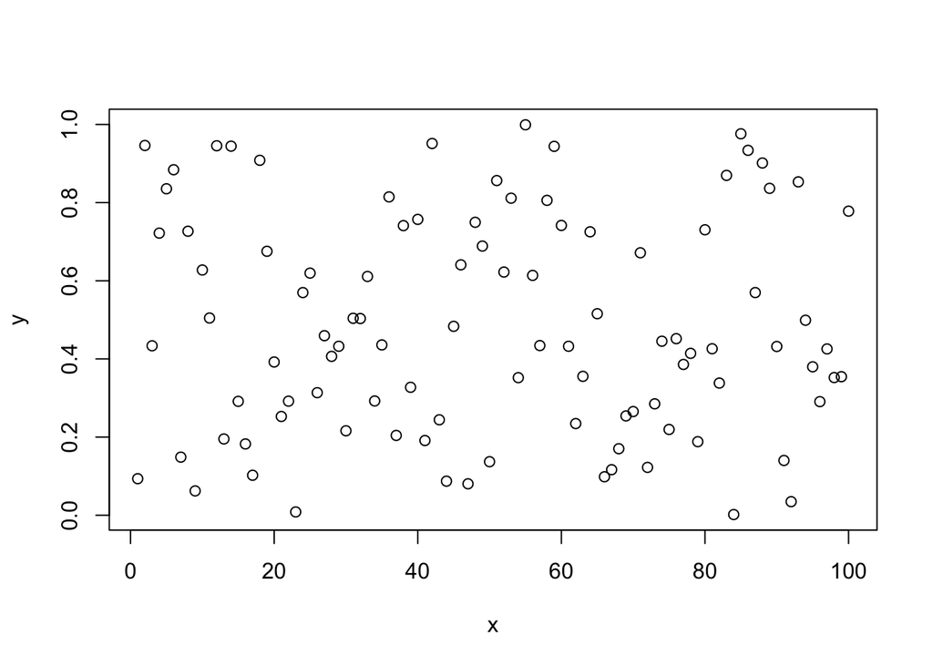

```r
x <- c(1:100)
y <-runif(100)
plot(x,y)
```

### 1.1 大小问题

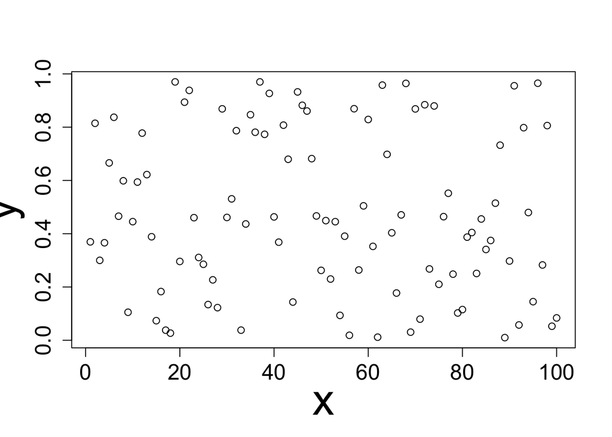

```r
x <- c(1:100)
y <-runif(100)
plot(x,y, cex.axis = 1.5, cex.lab = 3)
```

### 1.2 改变坐标轴刻度

通常我们想更换坐标轴刻度上显示的值，比如上图中x原来显示的数字，假如我们想改为“a,b,c,d……”，则可以通过如下方式实现：

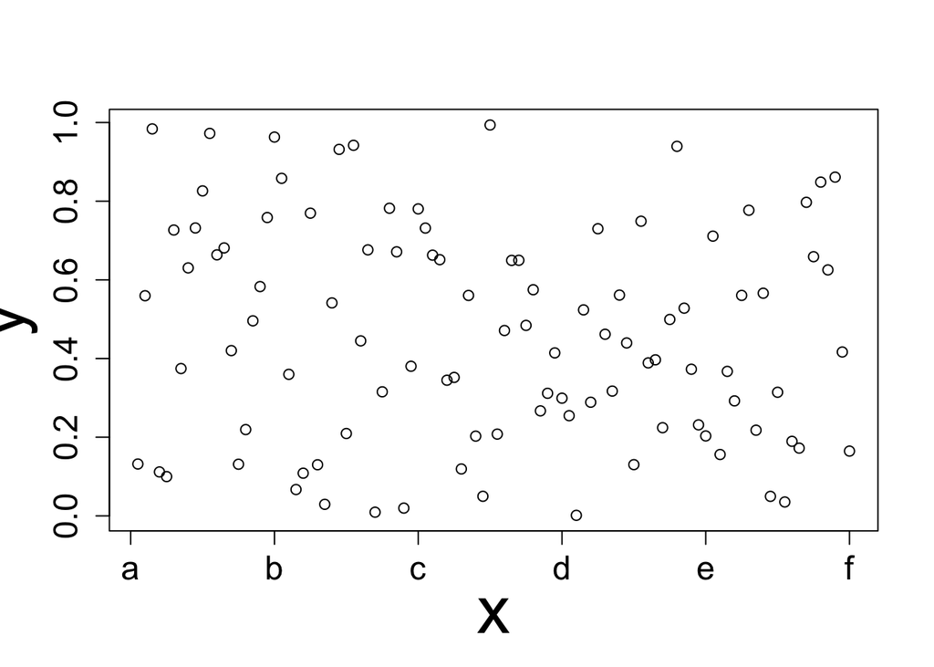

```r
x <- c(1:100)
y <-runif(100)
plot(x,y, cex.axis = 1.5, cex.lab = 3, xaxt = 'n')
axis(side=1, at=c(seq(0,100,20)), label = c('a','b','c','d','e','f'), cex.axis=1.5)
```

代码中参数的意思：

`side = 1`:设置坐标轴的位置， 1：下，2：左， 3：上，4：右。

`at = c(seq(0,100,20))` :要更改的坐标轴位置

`label = c('a','b','c','d','e','f')`: 更改的标签为 ‘a’,‘b’,‘c’,‘d’,‘e’,‘f’.

`cex.axis = 1.5`：刻度大小

### 1.3 额外参数

- 调整坐标轴刻度值离图像的距离：`padj`

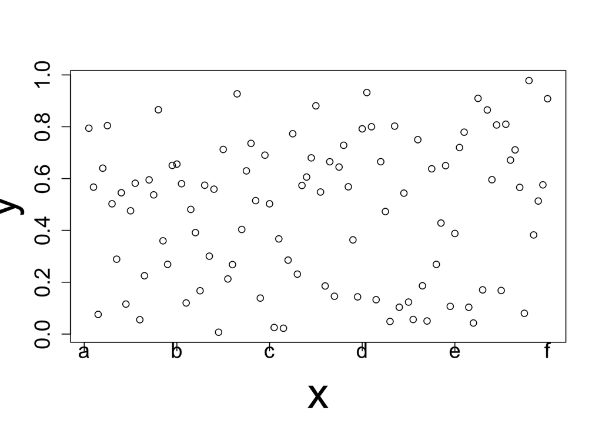

```r
x <- c(1:100)
y <-runif(100)
plot(x,y, cex.axis = 1.5, cex.lab = 3, xaxt = 'n')
axis(side=1, padj = -1, at=c(seq(0,100,20)), label = c('a','b','c','d','e','f'), cex.axis=1.5)
```

- 调整坐标label的位置

目前，我知道的方法是使用一个函数，而不是通过调参去改变：`mtext("x1", side = 1, line = 2.2,cex=2)`

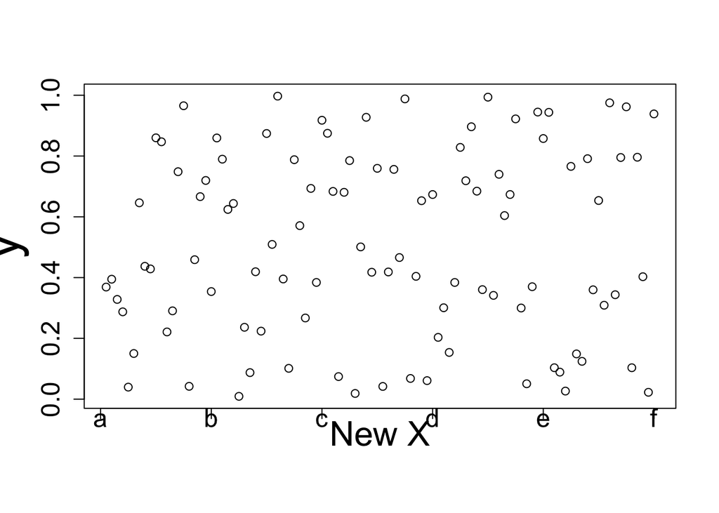

```r
x <- c(1:100)
y <-runif(100)
plot(x,y, cex.axis = 1.5, cex.lab = 3, xaxt = 'n', xlab="")
axis(side=1, padj = -1, at=c(seq(0,100,20)), label = c('a','b','c','d','e','f'), cex.axis=1.5)
mtext(text = "New X", side = 1, line = 1,cex=2)
```

使用mtext时，首先需要在plot函数中添加参数`xlab =''`，意思是设置x轴的label为空，这样就不会显示在图片上。 mtext函数中`text`参数就是我们要设置的坐标轴标题， `line`控制坐标轴标题离图像的距离。

- 调整坐标轴刻度线

`tcl`， 默认值为-0.5，负值表示刻度线朝外，正值朝里

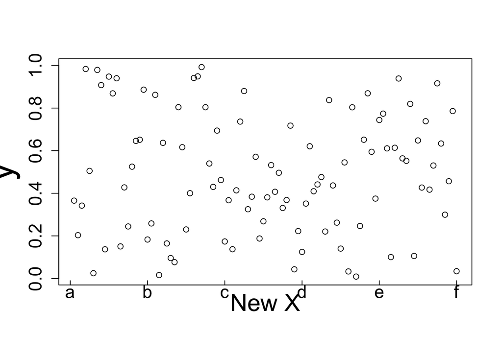

```r
x <- c(1:100)
y <-runif(100)
plot(x,y, cex.axis = 1.5, cex.lab = 3, xaxt = 'n', xlab="")
axis(side=1, padj = -1, at=c(seq(0,100,20)), label = c('a','b','c','d','e','f'), cex.axis=1.5, tcl = 0.3)
mtext(text = "New X", side = 1, line = 1,cex=2)
```

## ggplot2

首先画个简单的图

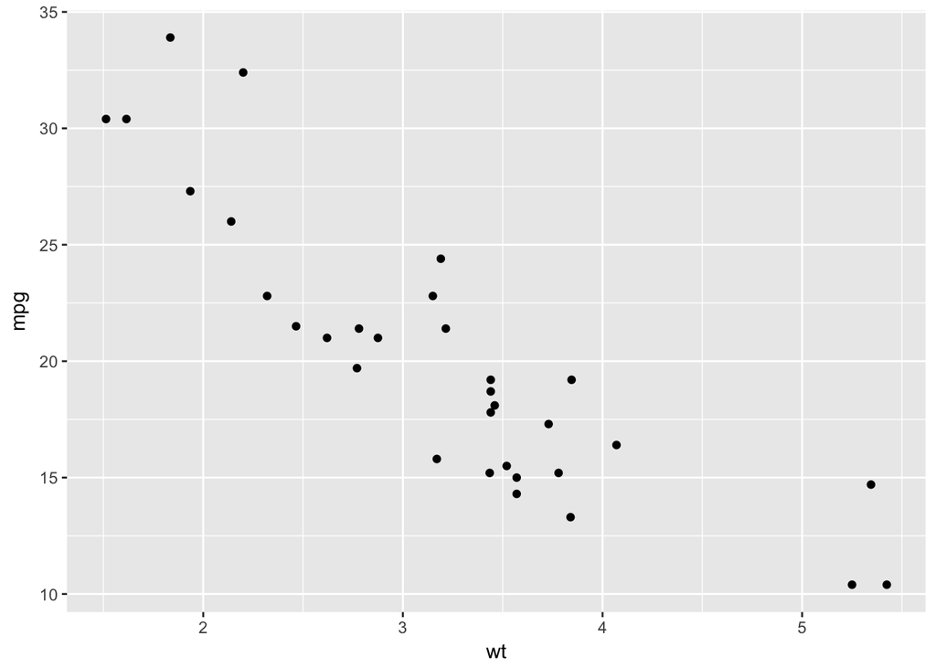

```r
library(ggplot2)
p <- ggplot(mtcars, aes(wt, mpg))
p + geom_point()
```

### 2.1 坐标轴范围

`xlim()`或者`ylim()`

### 2.2 调整坐标轴标题

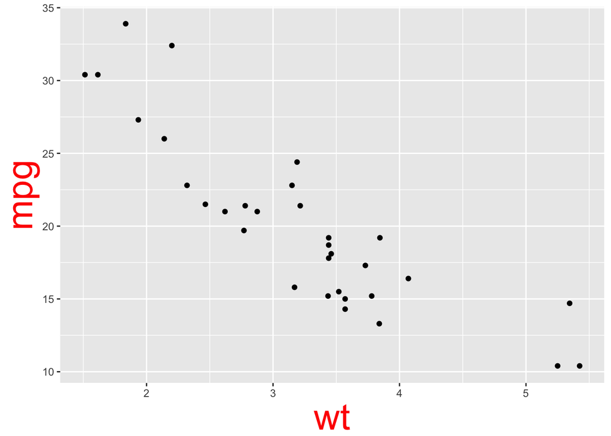

```r
library(ggplot2)
p <- ggplot(mtcars, aes(wt, mpg))
p + geom_point() + theme(axis.title = element_text(size=30, color = "red"))
```

### 2.3 调整坐标轴刻度值

`theme(axis.text = element_text(size = 15, color = 'blue', angle = 45))`

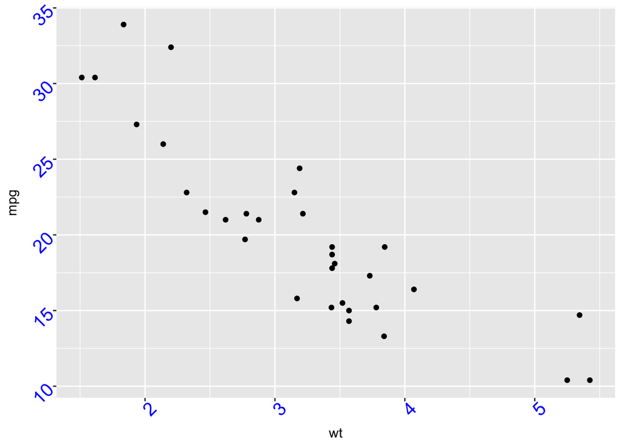

```r
library(ggplot2)
p <- ggplot(mtcars, aes(wt, mpg))
p + geom_point() + theme(axis.text = element_text(size = 15, color = 'blue', angle = 45))
```

比较2.2节中调节坐标轴标题的代码，不同的地方就仅在于`theme()`函数中`axis.title`变为`axis.text`。

另外还能单独只调整x轴或者y轴，只需要在参数后面加上`.x`或者`.y`，例如`axis.title.x`。

# 2.3 其他设置

- 删除网格线

`theme(panel.grid =element_blank())`

- 删除刻度线

`theme(axis.ticks = element_blank())`

- 重新设置坐标轴标题

`labs(x = "new x", y = "new y", title = "Title")`

或者

`xlab("这是 X 轴") + ylab("这是 Y 轴") + ggtitle("这是标题")`

- 标题居中

`theme(plot.title = element_text(hjust = 0.5))`

- 去除背景

`theme(panel.background = element_blank())`

- 添加坐标线

`theme(axis.line = element_line(colour = "grey"))`

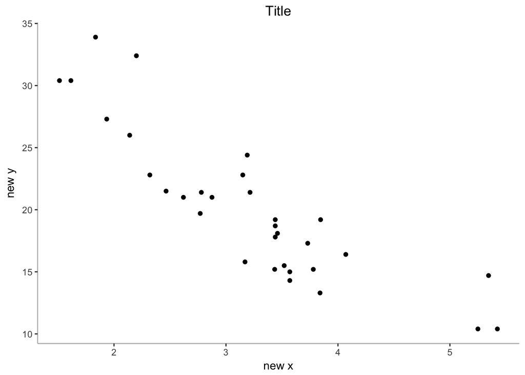

```r
library(ggplot2)
p <- ggplot(mtcars, aes(wt, mpg))
p + geom_point() + theme(panel.grid =element_blank()) + labs(x = "new x", y = "new y", title = "Title") + theme(plot.title = element_text(hjust = 0.5)) +theme(panel.background = element_blank(), axis.line = element_line(colour = "grey"))
```